# **Project CLV Sebastian Lemos**

#### ID TI1007335 group ABD-07

### **Customer Lifetime Value**

Customer lifetime value (CLV) is a business metric that measures how much a business can plan to earn from the average customer over the course of the relationship. Differences in products, costs, purchase frequencies and purchase volumes can make customer lifetime value calculations complex.

Customer lifetime value (CLV) is a measure of the total income a business can expect to bring in from a typical customer for as long as that person or account remains a client.

When measuring CLV, it’s best to look at the total average revenue generated by a customer and the total average profit. Each provides important insights into how customers interact with your business and if your overall marketing plan is working as expected.

[figure not shown]

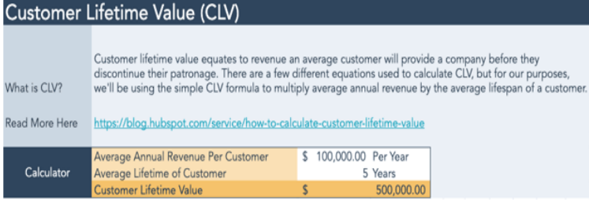

Use the below reference links to understand how to calculate CLV and write a report on visiting Tim Hortons.

**Exercise 1 :**

Write down the step involved in solving the above question.

1. First we have to do is understand the mathematical formula for calculate the CLV

**CLV = AARPC * ALC**

###### where:

###### CLV -> Customer lifetime value

###### AARPC -> Average annual revenue per customer

###### ALC -> Average Lifetime of customers

2. Identify the variables involve on the problem we have to solve:

a ) Average spending for visit = $6.45

2. Recurrence of visits = 3 times a week
3. Average spending for week = $6.45 * 3 = $19.35
4. Weeks a year = 365/7 = 52.14
5. Average spending a year = $19.35 * 52.14 = $1,008.96
6. AARPC = Average spending a year per customer * number of customers = $1,008.96 * 1 = $1,008.96
7. ALC = (Today’s date - Starting date)/365 = (#15/03/2023# - #01/01/2020#)/365 = 3.2 years
8. CLV = 1,008.96 * 3.2 = $3,231.45

```r
#Function CLV
CLV <- function(AARPC, ALC){
  CLV = AARPC * ALC
  as.numeric(return(CLV))
}
# Variables declaration
Avarage_spending_per_visit<- 6.45
Recurrence_of_visits<- 3
Numer_of_customers<- 1
weeks_a_year = 365/7
Today_date <- as.Date('2023-03-15')
Starting_date <- as.Date("2020-01-01")

# calculations
Average_spending_per_week<-Avarage_spending_per_visit * Recurrence_of_visits
Avarage_spending_a_year <- weeks_a_year * Average_spending_per_week
AARPC <- Avarage_spending_a_year * Numer_of_customers
ALC<- as.numeric(difftime(Today_date, Starting_date, units = "days")/365)
#executing the function CLV
CLV(AARPC,ALC)
```

```
## [1] 3231.45
```

**Exercise 2 :**

Use the data and calculate the CLV by adding the profit margin of 25%.

In order to complete the task we must re understand the CLV Formula by adding to it the concept of profit margin. To do so we must resort to a definition given by one of the references of the exercise which says that gross margin is the same concept as profit margin.

“AGM is the average gross margin, which tells you what part of each sale is your actual profit…”

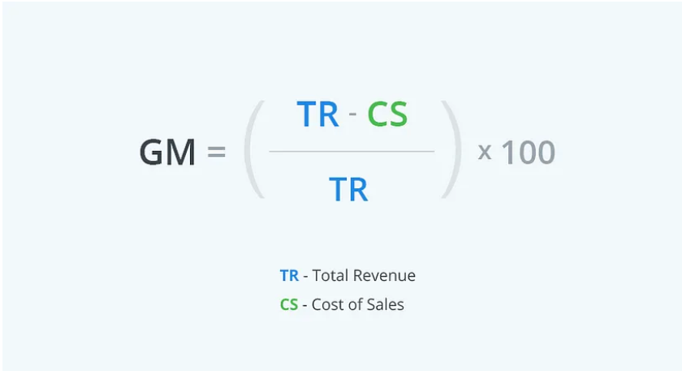

##### Source : https://medium.com/swlh/5-simple-ways-to-calculate-customer-lifetime-value-5f49b1a12723

Now, using this concept and assuming that the cost of sales remains the same or fixed regardless of the number of products sold, we could deduce that adding 25% to the gross margin would be the same as adding 25% to the price of the products, which leads us to determine that adding 25% to the total revenue would be adding 25% to the gross margin or profit margin.

Now that we clarify the concept of CLV we could continue with the exercise by importing the data given to us to work.

```r
Base_ventas <- read.csv("G:/Mi unidad/trebas info/customer_eval2.csv")
```

Then we evaluate the data imported structure and make changes if necesary

```r
str(Base_ventas)
```

```
## 'data.frame':    999 obs. of  8 variables:
##  $ InvoiceNo  : chr  "536365" "536365" "536365" "536365" ...
##  $ StockCode  : chr  "85123A" "71053" "84406B" "84029G" ...
##  $ Description: chr  "WHITE HANGING HEART T-LIGHT HOLDER" "WHITE METAL LANTERN" "CREAM CUPID HEARTS COAT HANGER" "KNITTED UNION FLAG HOT WATER BOTTLE" ...
##  $ Quantity   : int  6 6 8 6 6 2 6 6 6 NA ...
##  $ InvoiceDate: chr  "12/1/2010 8:26" "12/1/2010 8:26" "12/1/2010 8:26" "12/1/2010 8:26" ...
##  $ UnitPrice  : num  NA NA 2.75 3.39 3.39 7.65 4.25 1.85 1.85 1.69 ...
##  $ CustomerID : int  17850 17850 17850 17850 17850 17850 17850 17850 17850 13047 ...
##  $ Country    : chr  "United Kingdom" "United Kingdom" "United Kingdom" "United Kingdom" ...
```

In this case, everything seems to be good, because the data is a data frame, columns Quantity and UnitPrice are numeric, and the dimension of the data base is correct. so we could proceed next.

Then, we must fix the data:

```r
library(dplyr)
```

```r
library(tidyr)

#We first use a filter to delete rows with NA on column Quantity because without that information is impossible to work

#Then we separate the information By groups attached to the column "description"

#Finally, we replace NA from column UnitPrice with the average figure of the correspondent group

Base_ventas_fixed <- Base_ventas %>%
  filter(!is.na(Base_ventas$Quantity))%>%
  group_by(Description) %>%
  mutate_at(vars(UnitPrice), ~replace_na(., mean(., na.rm = TRUE)))
Base_ventas_fixed
```

```
## # A tibble: 998 × 8
## # Groups:   Description [591]
##    InvoiceNo StockCode Description       Quant…¹ Invoi…² UnitP…³ Custo…⁴ Country
##    <chr>     <chr>     <chr>               <int> <chr>     <dbl>   <int> <chr>
##  1 536365    85123A    "WHITE HANGING H…       6 12/1/2…    2.68   17850 United…
##  2 536365    71053     "WHITE METAL LAN…       6 12/1/2…    3.39   17850 United…
##  3 536365    84406B    "CREAM CUPID HEA…       8 12/1/2…    2.75   17850 United…
##  4 536365    84029G    "KNITTED UNION F…       6 12/1/2…    3.39   17850 United…
##  5 536365    84029E    "RED WOOLLY HOTT…       6 12/1/2…    3.39   17850 United…
##  6 536365    22752     "SET 7 BABUSHKA …       2 12/1/2…    7.65   17850 United…
##  7 536365    21730     "GLASS STAR FROS…       6 12/1/2…    4.25   17850 United…
##  8 536366    22633     "HAND WARMER UNI…       6 12/1/2…    1.85   17850 United…
##  9 536366    22632     "HAND WARMER RED…       6 12/1/2…    1.85   17850 United…
## 10 536367    22745     "POPPY'S PLAYHOU…       6 12/1/2…    2.1    13047 United…
## # … with 988 more rows, and abbreviated variable names ¹Quantity, ²InvoiceDate,
## #   ³UnitPrice, ⁴CustomerID
```

Once we have fixed the data base we could ad a new column adding 25% to the unit price, and other calculating the total sales.

```r
Base_ventas_fixed$New_unit_price <- Base_ventas_fixed$UnitPrice *1.25
Base_ventas_fixed$Total_sales <- Base_ventas_fixed$New_unit_price*Base_ventas_fixed$Quantity
```

```r
#calculations
Numer_of_customers<- n_distinct(Base_ventas_fixed$CustomerID)
Avarage_spending_a_year <- sum(Base_ventas_fixed$Total_sales) / Numer_of_customers
AARPC <-  Avarage_spending_a_year * Numer_of_customers
ALC <- 1/365

#executing the function CLV
CLV(AARPC,ALC)
```

```
## [1] 83.73449
```

**Exercise 3 :**

Evaluate the CLV for following customer, whose purchases for two year is more than 2000

For giving answer to this question we need create a new data base resumed by ID client, with the averages sales of each customer. and then multiply it for 730 days, and finally make a filter so check which customer has more than 2,000 in the final result.

```r
Base_resumida <- Base_ventas_fixed%>%
  group_by(CustomerID) %>%
  summarize(mean_sales = mean(Total_sales))

Base_resumida$TwoYearAvSales <- Base_resumida$mean_sales * 730

Base_resumida_filtrada <- Base_resumida%>%
  filter(Base_resumida$TwoYearAvSales> 2000)
Base_resumida_filtrada
```

```
## # A tibble: 46 × 3
##    CustomerID mean_sales TwoYearAvSales
##         <int>      <dbl>          <dbl>
##  1      12431      32.0          23350.
##  2      12583      53.5          39049.
##  3      12791     120.           87874.
##  4      12838       8.28          6044.
##  5      13047      24.4          17825.
##  6      13255      47.0          34325.
##  7      13408     116.           85002.
##  8      13448      30.8          22506.
##  9      13694     175.          128072.
## 10      13705      39.8          29030.
## # … with 36 more rows
```

```r
paste("Acording to the result we could say that ", length(Base_resumida_filtrada$CustomerID), "out of ",length(Base_resumida$CustomerID), "Customers have a two-year CLV above $2,000")
```

```
## [1] "Acording to the result we could say that  46 out of  49 Customers have a two-year CLV above $2,000"
```